# MIS40970 Data Mining - Assignment 3 Classification

Shruti Goyal (16200726)

```r
#rm() is used to remove other objects from the environment
rm(list=ls())
#To check the working directory
getwd()
```

```
[1] "G:/R_programs_git/R_Progams/Classification/Classification"
```

```r
#A specific working drectory needs to be set for the loading of dataset
setwd("G:/R_programs_git/R_Progams/Classification/Classification")
```

## **Q1 Compare and contrast classification and clustering.**

**Clustering** is a process of grouping objects together in a way that objects with similar features will be together and dissimilar objects will be together. It is used for data analysis.

**Classification** is a method of categorization where objects are recognised, differentiated on basis of training dataset.

1. **Supervision** : Classification - Supervised learning Clustering - Unsupervised learning
2. **Training set** : Classification - Find simmilarities using training set Clustering - No training set is used
3. **Process** : Classification - Categorise data as per observations in training set Clustering - Use statistical concepts and datasets are split with similar and dissimilar features
4. **Labels** : Classification - Use of labels Clustering - no labels
5. **Data Mining Methods** : Classification - It is a method of predicting instances from labeled instances Clustering - This methods identifies natural grouping of instances from unlabeled data

**Examples** : Classification - Random Forest, rpart, Ctree, Tree Clustering - kmeans, PAM, hierarchial

Both the methods are similar to each other as both divide the data into subsets and yet two different learning methods to get relevant information from raw data.

## **Q2 Describe what this piece of R code is doing and why it is an important starting point for running classification algorithm. ##> set.seed(1234) ##> dataPartition <- sample(2,nrow(data),replace=TRUE,prob=c(0.7,0.3)) ##> trainData <- data[dataPartition ==1,] ##> testData <- [dataPartition ==2,]**

Classification needs supervised learning where we need to partition the data which can be used to train dataset. To explain the above set of commands, data has been imported from college.csv file as shown below:

```r
#Importing library readr to load data from csv file
library(readr)
#Importing data from CSV in a variable college
college <- read_csv("G:/R_programs_git/R_Progams/Classification/Classification/college.csv")
set.seed(1234)
dataPartition <- sample(2,nrow(college),replace=TRUE,prob=c(0.7,0.3))
trainCollege <- college[dataPartition ==1,]
testCollege <- college[dataPartition ==2,]
```

For the first statement(**set.seed(1234)**), we use seed number as a starting point that is used to generate a sequence of pseudo random numbers. This function is important if there is need that results should be reproducible and debuggable easily.

Second statement(**dataPartition<-sample(2,nrow(data),replace=TRUE,prob=c(0.7,0.3))**) represents the properties of the partitions that need to be taken. Sample function takes a specified size from 2(an integer vector that can take one or more elements) so that function can generate random permutation of elements of vector(1:vector). If vector is 4, then the random permutation sequence will take numbers between 1 and 4 numbers. nrow(data) represents the size giving the numbers of items to choose and nrow is the last row of the college dataset. replace represents whether the sampling should be done with replacement or without replacement. Replace=TRUE is set to do the sampling with replacement. And prob will take probability weights for obtaining sampled elements. So it is expected that 1 will appear more than 2 times as weight is 0.7 than 0.3. If we write prob=c(0.3,0.5,0.2) then 1 is appeared to be less times than 2 but more than 3.

**trainCollege <- college[dataPartition ==1,] and testCollege <- college[dataPartition ==2,]** split the college dataset into 2 datasets i.e. Test data and Train data, where test data is used for testing.

All these commands will help in creating training dataset that can be changed continuously that help in formulation of classification algorithms.

## **Q3 What is the role of the M parameter in the Weka implementation of C4.5 algorithm? Which part of the DTL induction process does this parameter affect?**

While implementing C4.5 algorithm in Weka software, M parameter sets a minimum instances per leaf that effects the separation of data on the decision tree. Minimum of the instances have atleast two branches will be at each split.As a result, there will be effect on the total number of tree formulated.

```r
#Installing Weka package
install.packages("RWeka")
```

## **Q4. Install R package “C50”. Import customer churn dataset (churn) using data() function. Examine the churnTrain dataset. Using R run a decision-tree classification algorithm of your choice constructing a full unpruned tree and a pruned tree. Compare classification results of the pruned and unpruned trees generated.**

```r
install.packages('C50')
library(C50)
#To examine datasets in package C50
data()
```

After examining data function, it has been found out that there are two datasets in ‘Customer Churn Data’ (C50 package), which are churnTest and churnTrain. To import datasets in C50 package, use command “data(churn)”.

```r
data(churn)
print("Details of attributes in churnTrain")
```

```
[1] "Details of attributes in churnTrain"
```

```r
print("___________________________________/n")
```

```
[1] "___________________________________/n"
```

```r
str(churnTrain)
```

```
'data.frame':   3333 obs. of  20 variables:
 $ state                        : Factor w/ 51 levels "AK","AL","AR",..: 17 36 32 36 37 2 20 25 19 50 ...
 $ account_length               : int  128 107 137 84 75 118 121 147 117 141 ...
 $ area_code                    : Factor w/ 3 levels "area_code_408",..: 2 2 2 1 2 3 3 2 1 2 ...
 $ international_plan           : Factor w/ 2 levels "no","yes": 1 1 1 2 2 2 1 2 1 2 ...
 $ voice_mail_plan              : Factor w/ 2 levels "no","yes": 2 2 1 1 1 1 2 1 1 2 ...
 $ number_vmail_messages        : int  25 26 0 0 0 0 24 0 0 37 ...
 $ total_day_minutes            : num  265 162 243 299 167 ...
 $ total_day_calls              : int  110 123 114 71 113 98 88 79 97 84 ...
 $ total_day_charge             : num  45.1 27.5 41.4 50.9 28.3 ...
 $ total_eve_minutes            : num  197.4 195.5 121.2 61.9 148.3 ...
 $ total_eve_calls              : int  99 103 110 88 122 101 108 94 80 111 ...
 $ total_eve_charge             : num  16.78 16.62 10.3 5.26 12.61 ...
 $ total_night_minutes          : num  245 254 163 197 187 ...
 $ total_night_calls            : int  91 103 104 89 121 118 118 96 90 97 ...
 $ total_night_charge           : num  11.01 11.45 7.32 8.86 8.41 ...
 $ total_intl_minutes           : num  10 13.7 12.2 6.6 10.1 6.3 7.5 7.1 8.7 11.2 ...
 $ total_intl_calls             : int  3 3 5 7 3 6 7 6 4 5 ...
 $ total_intl_charge            : num  2.7 3.7 3.29 1.78 2.73 1.7 2.03 1.92 2.35 3.02 ...
 $ number_customer_service_calls: int  1 1 0 2 3 0 3 0 1 0 ...
 $ churn                        : Factor w/ 2 levels "yes","no": 2 2 2 2 2 2 2 2 2 2 ...
```

```r
print("---------------------------Summary Table :churnTrain---------------------")
```

```
[1] "---------------------------Summary Table :churnTrain---------------------"
```

```r
#To understand dataset churnTrain
summary(churnTrain)
```

```
     state      account_length          area_code    international_plan
 WV     : 106   Min.   :  1.0   area_code_408: 838   no :3010
 MN     :  84   1st Qu.: 74.0   area_code_415:1655   yes: 323
 NY     :  83   Median :101.0   area_code_510: 840
 AL     :  80   Mean   :101.1
 OH     :  78   3rd Qu.:127.0
 OR     :  78   Max.   :243.0
 (Other):2824
 voice_mail_plan number_vmail_messages total_day_minutes total_day_calls
 no :2411        Min.   : 0.000        Min.   :  0.0     Min.   :  0.0
 yes: 922        1st Qu.: 0.000        1st Qu.:143.7     1st Qu.: 87.0
                 Median : 0.000        Median :179.4     Median :101.0
                 Mean   : 8.099        Mean   :179.8     Mean   :100.4
                 3rd Qu.:20.000        3rd Qu.:216.4     3rd Qu.:114.0
                 Max.   :51.000        Max.   :350.8     Max.   :165.0

 total_day_charge total_eve_minutes total_eve_calls total_eve_charge
 Min.   : 0.00    Min.   :  0.0     Min.   :  0.0   Min.   : 0.00
 1st Qu.:24.43    1st Qu.:166.6     1st Qu.: 87.0   1st Qu.:14.16
 Median :30.50    Median :201.4     Median :100.0   Median :17.12
 Mean   :30.56    Mean   :201.0     Mean   :100.1   Mean   :17.08
 3rd Qu.:36.79    3rd Qu.:235.3     3rd Qu.:114.0   3rd Qu.:20.00
 Max.   :59.64    Max.   :363.7     Max.   :170.0   Max.   :30.91

 total_night_minutes total_night_calls total_night_charge total_intl_minutes
 Min.   : 23.2       Min.   : 33.0     Min.   : 1.040     Min.   : 0.00
 1st Qu.:167.0       1st Qu.: 87.0     1st Qu.: 7.520     1st Qu.: 8.50
 Median :201.2       Median :100.0     Median : 9.050     Median :10.30
 Mean   :200.9       Mean   :100.1     Mean   : 9.039     Mean   :10.24
 3rd Qu.:235.3       3rd Qu.:113.0     3rd Qu.:10.590     3rd Qu.:12.10
 Max.   :395.0       Max.   :175.0     Max.   :17.770     Max.   :20.00

 total_intl_calls total_intl_charge number_customer_service_calls churn
 Min.   : 0.000   Min.   :0.000     Min.   :0.000                 yes: 483
 1st Qu.: 3.000   1st Qu.:2.300     1st Qu.:1.000                 no :2850
 Median : 4.000   Median :2.780     Median :1.000
 Mean   : 4.479   Mean   :2.765     Mean   :1.563
 3rd Qu.: 6.000   3rd Qu.:3.270     3rd Qu.:2.000
 Max.   :20.000   Max.   :5.400     Max.   :9.000
```

```r
churnTrain <- churnTrain[,c(-1,-4)]
print("Details of attributes in churnTrain after selecting few columns")
```

```
[1] "Details of attributes in churnTrain after selecting few columns"
```

```r
print("_______________________________________________________________")
```

```
[1] "_______________________________________________________________"
```

```r
str(churnTrain)
```

```
'data.frame':   3333 obs. of  18 variables:
 $ account_length               : int  128 107 137 84 75 118 121 147 117 141 ...
 $ area_code                    : Factor w/ 3 levels "area_code_408",..: 2 2 2 1 2 3 3 2 1 2 ...
 $ voice_mail_plan              : Factor w/ 2 levels "no","yes": 2 2 1 1 1 1 2 1 1 2 ...
 $ number_vmail_messages        : int  25 26 0 0 0 0 24 0 0 37 ...
 $ total_day_minutes            : num  265 162 243 299 167 ...
 $ total_day_calls              : int  110 123 114 71 113 98 88 79 97 84 ...
 $ total_day_charge             : num  45.1 27.5 41.4 50.9 28.3 ...
 $ total_eve_minutes            : num  197.4 195.5 121.2 61.9 148.3 ...
 $ total_eve_calls              : int  99 103 110 88 122 101 108 94 80 111 ...
 $ total_eve_charge             : num  16.78 16.62 10.3 5.26 12.61 ...
 $ total_night_minutes          : num  245 254 163 197 187 ...
 $ total_night_calls            : int  91 103 104 89 121 118 118 96 90 97 ...
 $ total_night_charge           : num  11.01 11.45 7.32 8.86 8.41 ...
 $ total_intl_minutes           : num  10 13.7 12.2 6.6 10.1 6.3 7.5 7.1 8.7 11.2 ...
 $ total_intl_calls             : int  3 3 5 7 3 6 7 6 4 5 ...
 $ total_intl_charge            : num  2.7 3.7 3.29 1.78 2.73 1.7 2.03 1.92 2.35 3.02 ...
 $ number_customer_service_calls: int  1 1 0 2 3 0 3 0 1 0 ...
 $ churn                        : Factor w/ 2 levels "yes","no": 2 2 2 2 2 2 2 2 2 2 ...
```

```r
set.seed(1234)
dataPart <- sample(2, nrow(churnTrain),replace = TRUE,prob = c(0.7,0.3))
traindata <- churnTrain[dataPart ==1,]
testdata <- churnTrain[dataPart ==2,]
#Installing package 'tree' for Decision Tree
install.packages("tree")
library(tree)
```

```r
#Grow a tree using tree to predict customer churn for all other independent variables
fit <- tree(traindata$churn ~ .,traindata)
#To print detailed summary of splits
summary(fit)
```

```
Classification tree:
tree(formula = traindata$churn ~ ., data = traindata)
Variables actually used in tree construction:
[1] "number_customer_service_calls" "total_day_minutes"
[3] "total_eve_minutes"             "total_intl_minutes"
[5] "total_intl_calls"              "voice_mail_plan"
[7] "total_night_minutes"
Number of terminal nodes:  14
Residual mean deviance:  0.4803 = 1128 / 2348
Misclassification error rate: 0.08171 = 193 / 2362
```

```r
cat("\n \n")
```

```r
#Prediction using predict function for both traindata and testdata
traindata_C50 = predict(fit,traindata,type="class")
testdata_C50 = predict(fit,testdata,type="class")
#Printing prediction result using table
print("Prediction of traindata")
```

```
[1] "Prediction of traindata"
```

```r
cat("_______________________\n")
```

```
_______________________
```

```r
table(traindata_C50,traindata$churn)
```

```
traindata_C50  yes   no
          yes  176   41
          no   152 1993
```

```r
cat("\n")
```

```r
print("Prediction of testdata")
```

```
[1] "Prediction of testdata"
```

```r
cat("______________________\n")
```

```
______________________
```

```r
table(testdata_C50,testdata$churn)
```

```
testdata_C50 yes  no
         yes  82  23
         no   73 793
```

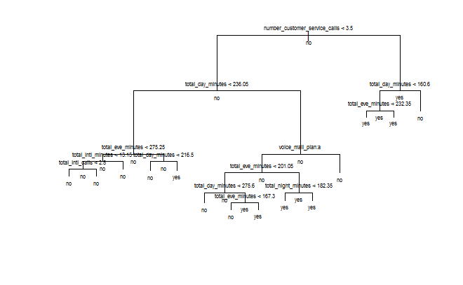

```r
#To plot the tree
plot(fit)
text(fit, all = TRUE, cex = 0.5)
```

```r
#Pruning the tree
pfit = cv.tree(fit,FUN = prune.misclass)
print("Details of prune.misclass")
```

```
[1] "Details of prune.misclass"
```

```r
print("_________________________")
```

```
[1] "_________________________"
```

```r
cat("\n")
```

```r
pfit
```

```
$size
[1] 14 10  8  7  6  3  1

$dev
[1] 226 226 225 228 232 277 328

$k
[1]     -Inf  0.00000  3.50000  6.00000 10.00000 18.66667 28.00000

$method
[1] "misclass"

attr(,"class")
[1] "prune"         "tree.sequence"
```

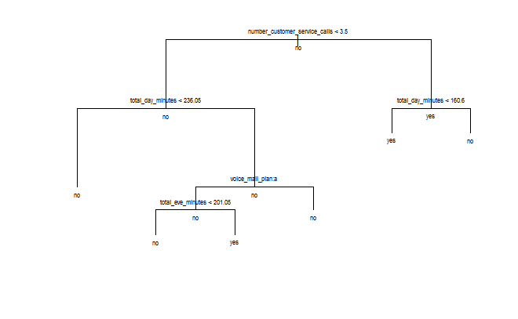

```r
pruneData = prune.misclass(fit,best=6)
#Plot the pruned tree
plot(pruneData)
text(pruneData,all = TRUE, cex = 0.5)
```

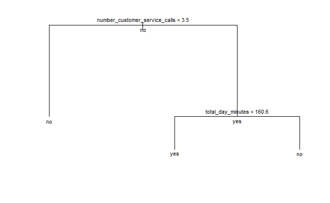

```r
pruneData2 = prune.misclass(fit,best=2)
#Plot the pruned tree
plot(pruneData2)
text(pruneData2,all = TRUE, cex = 0.7)
```

Pruning the decision tree will help to avoid overfitting the data. It will minimize the cross validation error (uing xerror) and select complexity parameter that is associated with least error. Results shows that unpruned tree is larger because the algorithm is implemented as is. While in pruned tree, there is an additional step which analyse which nodes or branches to be removed that will not affect the performance of decision tree.